# WEEK2_ASSIGNMENT

## ------------------------------------------------------------------------------------------------------------------------

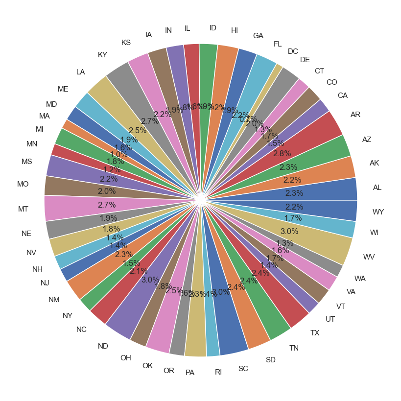

```python
fig=plt.figure(figsize=(10,10))
axes1=fig.add_axes([0.1,0.1,0.8,0.8])
plt.pie(df.total,labels=df.abbrev,autopct="%0.1f%%")
plt.show()
```

#### Inference:

It Shows the data in the form of pie while showing how much part of the data is taken by each abbrev

## ------------------------------------------------------------------------------------------------------------------------

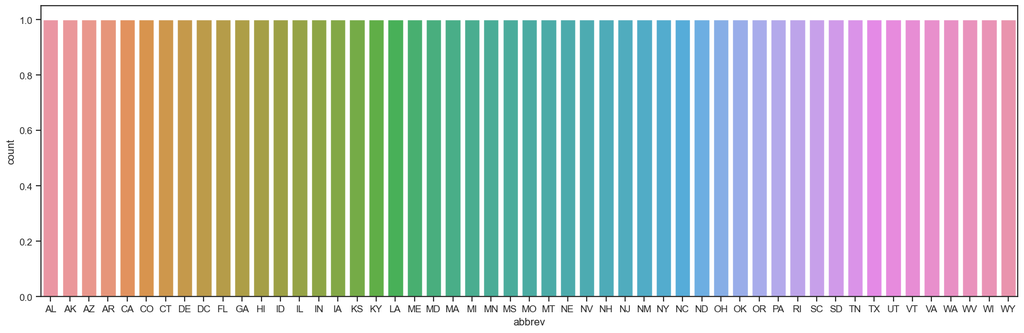

```python
fig=plt.figure(figsize=(20,6))
sns.countplot(x="abbrev", data=df)
```

#### Inference:

This plots the count of each type of abbrev as here each type is max of only 1 all the bars plots only to 1

## ------------------------------------------------------------------------------------------------------------------------

```python
df.corr()
```

|  | total | speeding | alcohol | not_distracted | no_previous | ins_premium | ins_losses |
| --- | --- | --- | --- | --- | --- | --- | --- |
| total | 1.000000 | 0.611548 | 0.852613 | 0.827560 | 0.956179 | -0.199702 | -0.036011 |
| speeding | 0.611548 | 1.000000 | 0.669719 | 0.588010 | 0.571976 | -0.077675 | -0.065928 |
| alcohol | 0.852613 | 0.669719 | 1.000000 | 0.732816 | 0.783520 | -0.170612 | -0.112547 |
| not_distracted | 0.827560 | 0.588010 | 0.732816 | 1.000000 | 0.747307 | -0.174856 | -0.075970 |
| no_previous | 0.956179 | 0.571976 | 0.783520 | 0.747307 | 1.000000 | -0.156895 | -0.006359 |
| ins_premium | -0.199702 | -0.077675 | -0.170612 | -0.174856 | -0.156895 | 1.000000 | 0.623116 |
| ins_losses | -0.036011 | -0.065928 | -0.112547 | -0.075970 | -0.006359 | 0.623116 | 1.000000 |

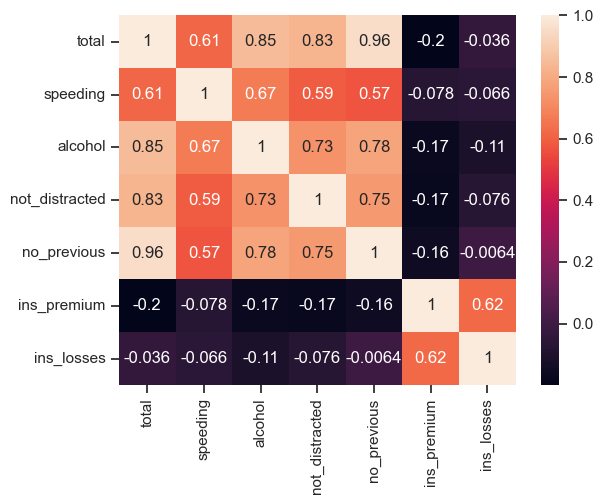

```python
sns.heatmap(df.corr(),annot=True)
```

#### Inference:

It shows us the correlation between the features of the data using different colors as per how much onee feature is dependent on another

### TUMMALA NIKHIL PHANEENDRA

#### 21BAI1345

#### +91 9759881111

#### tummalanikhil.phaneendra2021@vitstudent.ac.in